Back to Article

###### EDA on LIWC Features

Download Source

# EDA on LIWC Features

Author

Coco Yu

Published

October 8, 2024

## Setup

Chunk Defaults

```
In [1]:
```

```r
knitr::opts_chunk$set(attr.output='style="max-height: 500px;"')
```

Conflicts

```
In [2]:
```

```r
options(conflicts.policy = "depends.ok")
```

```
In [3]:
```

```r
library(tidyverse)
library(kableExtra, exclude = "group_rows")
library(lubridate)
library(janitor, include.only = c("tabyl", "clean_names"))
library(here, include.only = c("here"))
theme_set(theme_classic())
```

Source Functions

```
In [4]:
```

```r
devtools::source_url("https://github.com/jjcurtin/lab_support/blob/main/format_path.R?raw=true")
```

```
ℹ SHA-1 hash of file is "a58e57da996d1b70bb9a5b58241325d6fd78890f"
```

```r
devtools::source_url("https://github.com/jjcurtin/lab_support/blob/main/fun_eda.R?raw=true")
```

```
ℹ SHA-1 hash of file is "c045eee2655a18dc85e715b78182f176327358a7"
```

Absolute Paths

```
In [5]:
```

```r
path_messages <- format_path(str_c("studydata/risk/data_processed/messages"))
```

Read in Data

```
In [6]:
```

```r
liwc_ind <- read_csv(
  here(path_messages, "liwc", "liwc_features_long.csv"),
  col_types = cols()
)

liwc_cat <- read_csv(
  here(path_messages, "liwc", "liwc_features_cat.csv"),
  col_types = cols()
)
```

## EDA on liwc features generated on individual messages

sanity check: number of participants

```
In [7]:
```

```r
liwc_ind |>
  pull(subid) |>
  unique() |>
  length()
```

```
[1] 138
```

sanity check: # of labels

```
In [8]:
```

```r
(nrow(liwc_ind))
```

```
[1] 11562
```

sanity check: # of labels per participant (same with raw_message file)

```
In [9]:
```

```r
liwc_ind |>
  group_by(subid) |>
  summarize(n = n()) |>
  summarize(
    mean = mean(n),
    sd = sd(n),
    median = median(n),
    min = min(n),
    max = max(n)
  )
```

```
# A tibble: 1 × 5
   mean    sd median   min   max
  <dbl> <dbl>  <dbl> <int> <int>
1  83.8  11.4     88    30    90
```

sanity check: # of features for each prediction window

```
In [10]:
```

```r
liwc_ind |>
  select(ends_with("3day")) |>
  ncol()
```

```
[1] 234
```

```r
liwc_ind |>
  select(ends_with("1week")) |>
  ncol()
```

```
[1] 234
```

```r
liwc_ind |>
  select(ends_with("3day") | ends_with("1week")) |>
  ncol()
```

```
[1] 468
```

### sanity check: missingness

> **By lapse labels**

> checked the percentage of labels that lack liwc features match missingness on raw messages for 3day, and 1week prediction windows

> checked that the percentage of labels that lack liwc features in 1week prediction window and combined feature sets match (both 7.83%)

```
In [11]:
```

```r
liwc_ind |>
  select(ends_with("3day")) |>
  rowwise() |>
  mutate(na = if_else(all(is.na(across(everything()))), 1, 0)) |>
  ungroup() |>
  pull(na) |>
  mean()
```

```
[1] 0.1191835
```

```r
liwc_ind |>
  select(ends_with("1week")) |>
  rowwise() |>
  mutate(na = if_else(all(is.na(across(everything()))), 1, 0)) |>
  ungroup() |>
  pull(na) |>
  mean()
```

```
[1] 0.07827366
```

```r
liwc_ind |>
  select(ends_with("3day") | ends_with("1week")) |>
  rowwise() |>
  mutate(na = if_else(all(is.na(across(everything()))), 1, 0)) |>
  ungroup() |>
  pull(na) |>
  mean()
```

```
[1] 0.07827366
```

> **By subject**

> checked the percentage of missingness per participant match between raw messages and liwc features for 3day and 1week prediction windows separately

> checked that the missingness per participant in 1week prediction window and combined feature sets match

```
In [12]:
```

```r
liwc_ind |>
  select(ends_with("3day"), subid, day_start) |>
  group_by(subid, day_start) |>
  summarize(
    missingness = if_else(all(is.na(across(everything()))), 1, 0)
  ) |>
  group_by(subid) |>
  summarize(
    mean_missing = mean(missingness)
  ) |>
  summarize(
    mean_mean_missing = mean(mean_missing),
    sd_mean_missing = sd(mean_missing),
    median_mean_missing = median(mean_missing),
    min_mean_missing = min(mean_missing),
    max_mean_missing = max(mean_missing)
  ) |>
  print_kbl()
```

| mean_mean_missing | sd_mean_missing | median_mean_missing | min_mean_missing | max_mean_missing |
| --- | --- | --- | --- | --- |
| 0.12 | 0.19 | 0.01 | 0 | 0.77 |

```r
liwc_ind |>
  select(ends_with("1week"), subid, day_start) |>
  group_by(subid, day_start) |>
  summarize(
    missingness = if_else(all(is.na(across(everything()))), 1, 0)
  ) |>
  group_by(subid) |>
  summarize(
    mean_missing = mean(missingness)
  ) |>
  summarize(
    mean_mean_missing = mean(mean_missing),
    sd_mean_missing = sd(mean_missing),
    median_mean_missing = median(mean_missing),
    min_mean_missing = min(mean_missing),
    max_mean_missing = max(mean_missing)
  ) |>
  print_kbl()
```

| mean_mean_missing | sd_mean_missing | median_mean_missing | min_mean_missing | max_mean_missing |
| --- | --- | --- | --- | --- |
| 0.08 | 0.16 | 0 | 0 | 0.73 |

```r
liwc_ind |>
  select(-label_num, -lapse) |>
  group_by(subid, day_start) |>
  summarize(
    missingness = if_else(all(is.na(across(everything()))), 1, 0)
  ) |>
  group_by(subid) |>
  summarize(
    mean_missing = mean(missingness)
  ) |>
  summarize(
    mean_mean_missing = mean(mean_missing),
    sd_mean_missing = sd(mean_missing),
    median_mean_missing = median(mean_missing),
    min_mean_missing = min(mean_missing),
    max_mean_missing = max(mean_missing)
  ) |>
  print_kbl()
```

| mean_mean_missing | sd_mean_missing | median_mean_missing | min_mean_missing | max_mean_missing |
| --- | --- | --- | --- | --- |
| 0.08 | 0.16 | 0 | 0 | 0.73 |

### EDA on features

```
In [13]:
```

```r
skim_minimal <- skimr::skim_with(numeric = skimr::sfl(mean = NULL, p25 = NULL,
                                                      p75 = NULL,
                                                      hist = NULL))

stats_ind <- liwc_ind |>
  select(ends_with("3day"), ends_with("1week")) |>
  skim_minimal() |>
  select(-n_missing)

stats_ind |>
  arrange(numeric.sd, numeric.p50) |>
  print_kbl()
```

| skim_type | skim_variable | complete_rate | numeric.sd | numeric.p0 | numeric.p50 | numeric.p100 |
| --- | --- | --- | --- | --- | --- | --- |
| numeric | politic_median_3day | 0.88 | 0.00 | 0.00 | 0.00 | 0.00 |
| numeric | sexual_median_3day | 0.88 | 0.00 | 0.00 | 0.00 | 0.00 |
| numeric | politic_median_1week | 0.92 | 0.00 | 0.00 | 0.00 | 0.00 |
| numeric | mental_median_1week | 0.92 | 0.00 | 0.00 | 0.00 | 0.00 |
| numeric | substances_median_1week | 0.92 | 0.00 | 0.00 | 0.00 | 0.00 |
| numeric | sexual_median_1week | 0.92 | 0.00 | 0.00 | 0.00 | 0.00 |
| numeric | lack_median_1week | 0.92 | 0.00 | 0.00 | 0.00 | 0.00 |
| numeric | reward_median_1week | 0.92 | 0.00 | 0.00 | 0.00 | 0.00 |
| numeric | filler_median_1week | 0.92 | 0.00 | 0.00 | 0.00 | 0.00 |
| numeric | filler_median_3day | 0.88 | 0.00 | 0.00 | 0.00 | 0.11 |
| numeric | wellness_median_1week | 0.92 | 0.00 | 0.00 | 0.00 | 0.14 |
| numeric | fulfill_median_1week | 0.92 | 0.00 | 0.00 | 0.00 | 0.14 |
| numeric | ethnicity_median_1week | 0.92 | 0.00 | 0.00 | 0.00 | 0.23 |
| numeric | ethnicity_median_3day | 0.88 | 0.00 | 0.00 | 0.00 | 0.23 |
| numeric | fulfill_median_3day | 0.88 | 0.00 | 0.00 | 0.00 | 0.18 |
| numeric | nonflu_median_1week | 0.92 | 0.00 | 0.00 | 0.00 | 0.35 |
| numeric | relig_median_1week | 0.92 | 0.00 | 0.00 | 0.00 | 0.16 |
| numeric | moral_median_1week | 0.92 | 0.00 | 0.00 | 0.00 | 0.22 |
| numeric | certitude_median_1week | 0.92 | 0.00 | 0.00 | 0.00 | 0.15 |
| numeric | emo_sad_median_1week | 0.92 | 0.00 | 0.00 | 0.00 | 0.13 |
| numeric | risk_median_1week | 0.92 | 0.00 | 0.00 | 0.00 | 0.29 |
| numeric | emo_sad_median_3day | 0.88 | 0.00 | 0.00 | 0.00 | 0.17 |
| numeric | curiosity_median_1week | 0.92 | 0.00 | 0.00 | 0.00 | 0.23 |
| numeric | substances_median_3day | 0.88 | 0.00 | 0.00 | 0.00 | 0.32 |
| numeric | nonflu_median_3day | 0.88 | 0.00 | 0.00 | 0.00 | 0.35 |
| numeric | emo_anx_median_1week | 0.92 | 0.00 | 0.00 | 0.00 | 0.28 |
| numeric | lack_median_3day | 0.88 | 0.00 | 0.00 | 0.00 | 0.48 |
| numeric | memory_median_1week | 0.92 | 0.01 | 0.00 | 0.00 | 0.19 |
| numeric | swear_median_1week | 0.92 | 0.01 | 0.00 | 0.00 | 0.44 |
| numeric | mental_median_3day | 0.88 | 0.01 | 0.00 | 0.00 | 0.43 |

[output cut: 438 more lines]

```
In [14]:
```

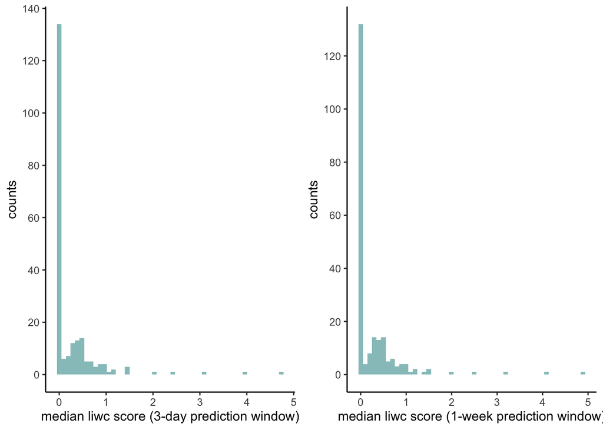

```r
cowplot::plot_grid(
  stats_ind |>
    filter(!str_detect(skim_variable, "wc|wps|analytic|tone|clout|authentic")) |>
    filter(str_detect(skim_variable, "3day")) |>
    # filter(numeric.p50 != 0) |>
    ggplot(aes(x = numeric.p50)) +
    geom_histogram(fill = "#97C4C5", bins = 50) +
    scale_y_continuous(breaks = seq(0, 160, by = 20)) +
    labs(x = "median liwc score (3-day prediction window)", y = "counts"),
  stats_ind |>
    filter(!str_detect(skim_variable, "wc|wps|analytic|tone|clout|authentic")) |>
    filter(str_detect(skim_variable, "1week")) |>
    # filter(numeric.p50 != 0) |>
    ggplot(aes(x = numeric.p50)) +
    geom_histogram(fill = "#97C4C5", bins = 50) +
    scale_y_continuous(breaks = seq(0, 160, by = 20)) +
    labs(x = "median liwc score (1-week prediction window)", y = "counts")
)
```

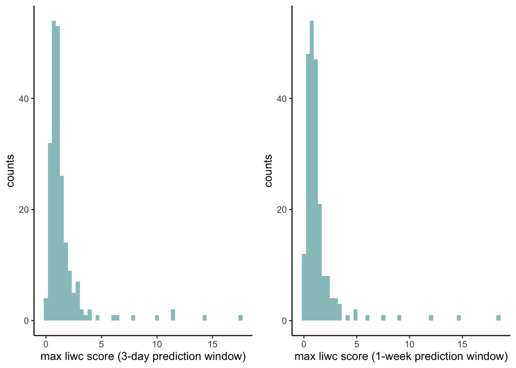

```r
cowplot::plot_grid(
  stats_ind |>
    filter(!str_detect(skim_variable, "wc|wps|analytic|tone|clout|authentic")) |>
    filter(str_detect(skim_variable, "3day")) |>
    ggplot(aes(x = numeric.p100)) +
    geom_histogram(fill = "#97C4C5", bins = 50) +
    scale_y_continuous(breaks = seq(0, 100, by = 20)) +
    labs(x = "max liwc score (3-day prediction window)", y = "counts"),
  stats_ind |>
    filter(!str_detect(skim_variable, "wc|wps|analytic|tone|clout|authentic")) |>
    filter(str_detect(skim_variable, "1week")) |>
    ggplot(aes(x = numeric.p100)) +
    geom_histogram(fill = "#97C4C5", bins = 50) +
    scale_y_continuous(breaks = seq(0, 100, by = 20)) +
    labs(x = "max liwc score (1-week prediction window)", y = "counts")
)
```

## EDA on concatenated messages

sanity check: number of participants

```
In [15]:
```

```r
liwc_cat |>
  pull(subid) |>
  unique() |>
  length()
```

```
[1] 138
```

sanity check: # of labels

```
In [16]:
```

```r
(nrow(liwc_cat))
```

```
[1] 11562
```

sanity check: # of labels per participant (same with raw_message file)

```
In [17]:
```

```r
liwc_cat |>
  group_by(subid) |>
  summarize(n = n()) |>
  summarize(
    mean = mean(n),
    sd = sd(n),
    median = median(n),
    min = min(n),
    max = max(n)
  )
```

```
# A tibble: 1 × 5
   mean    sd median   min   max
  <dbl> <dbl>  <dbl> <int> <int>
1  83.8  11.4     88    30    90
```

sanity check: # of features for each prediction window

```
In [18]:
```

```r
liwc_cat |>
  select(ends_with("3day")) |>
  ncol()
```

```
[1] 234
```

```r
liwc_cat |>
  select(ends_with("1week")) |>
  ncol()
```

```
[1] 234
```

```r
liwc_cat |>
  select(ends_with("3day") | ends_with("1week")) |>
  ncol()
```

```
[1] 468
```

### sanity check: missingness

> **By lapse labels**

> checked the percentage of labels that lack liwc features match missingness on raw messages for 3day, and 1week prediction windows

> checked that the percentage of labels that lack liwc features in 1week prediction window and combined feature sets match (both 7.83%)

```
In [19]:
```

```r
liwc_cat |>
  select(ends_with("3day")) |>
  rowwise() |>
  mutate(na = if_else(all(is.na(across(everything()))), 1, 0)) |>
  ungroup() |>
  pull(na) |>
  mean()
```

```
[1] 0.1191835
```

```r
liwc_cat |>
  select(ends_with("1week")) |>
  rowwise() |>
  mutate(na = if_else(all(is.na(across(everything()))), 1, 0)) |>
  ungroup() |>
  pull(na) |>
  mean()
```

```
[1] 0.07827366
```

```r
liwc_cat |>
  select(ends_with("3day") | ends_with("1week")) |>
  rowwise() |>
  mutate(na = if_else(all(is.na(across(everything()))), 1, 0)) |>
  ungroup() |>
  pull(na) |>
  mean()
```

```
[1] 0.07827366
```

> **By subject**

> checked the percentage of missingness per participant match between raw messages and liwc features for 3day and 1week prediction windows separately

> checked that the missingness per participant in 1week prediction window and combined feature sets match

```
In [20]:
```

```r
liwc_cat |>
  select(ends_with("3day"), subid, day_start) |>
  group_by(subid, day_start) |>
  summarize(
    missingness = if_else(all(is.na(across(everything()))), 1, 0)
  ) |>
  group_by(subid) |>
  summarize(
    mean_missing = mean(missingness)
  ) |>
  summarize(
    mean_mean_missing = mean(mean_missing),
    sd_mean_missing = sd(mean_missing),
    median_mean_missing = median(mean_missing),
    min_mean_missing = min(mean_missing),
    max_mean_missing = max(mean_missing)
  ) |>
  print_kbl()
```

| mean_mean_missing | sd_mean_missing | median_mean_missing | min_mean_missing | max_mean_missing |
| --- | --- | --- | --- | --- |
| 0.12 | 0.19 | 0.01 | 0 | 0.77 |

```r
liwc_cat |>
  select(ends_with("1week"), subid, day_start) |>
  group_by(subid, day_start) |>
  summarize(
    missingness = if_else(all(is.na(across(everything()))), 1, 0)
  ) |>
  group_by(subid) |>
  summarize(
    mean_missing = mean(missingness)
  ) |>
  summarize(
    mean_mean_missing = mean(mean_missing),
    sd_mean_missing = sd(mean_missing),
    median_mean_missing = median(mean_missing),
    min_mean_missing = min(mean_missing),
    max_mean_missing = max(mean_missing)
  ) |>
  print_kbl()
```

| mean_mean_missing | sd_mean_missing | median_mean_missing | min_mean_missing | max_mean_missing |
| --- | --- | --- | --- | --- |
| 0.08 | 0.16 | 0 | 0 | 0.73 |

```r
liwc_cat |>
  select(-label_num, -lapse) |>
  group_by(subid, day_start) |>
  summarize(
    missingness = if_else(all(is.na(across(everything()))), 1, 0)
  ) |>
  group_by(subid) |>
  summarize(
    mean_missing = mean(missingness)
  ) |>
  summarize(
    mean_mean_missing = mean(mean_missing),
    sd_mean_missing = sd(mean_missing),
    median_mean_missing = median(mean_missing),
    min_mean_missing = min(mean_missing),
    max_mean_missing = max(mean_missing)
  ) |>
  print_kbl()
```

| mean_mean_missing | sd_mean_missing | median_mean_missing | min_mean_missing | max_mean_missing |
| --- | --- | --- | --- | --- |
| 0.08 | 0.16 | 0 | 0 | 0.73 |

### EDA on features

```
In [21]:
```

```r
stats_cat <- liwc_cat |>
  select(ends_with("3day"), ends_with("1week")) |>
  skim_minimal() |>
  select(-n_missing)

stats_cat |>
  arrange(numeric.sd, numeric.p50) |>
  print_kbl()
```

| skim_type | skim_variable | complete_rate | numeric.sd | numeric.p0 | numeric.p50 | numeric.p100 |
| --- | --- | --- | --- | --- | --- | --- |
| numeric | mental_norm_3day | 0.88 | 0.03 | 0.00 | 0.00 | 0.43 |
| numeric | mental_norm_1week | 0.92 | 0.03 | 0.00 | 0.00 | 0.31 |
| numeric | ethnicity_norm_3day | 0.88 | 0.03 | 0.00 | 0.00 | 0.88 |
| numeric | ethnicity_norm_1week | 0.92 | 0.03 | 0.00 | 0.00 | 0.54 |
| numeric | reward_norm_3day | 0.88 | 0.04 | 0.00 | 0.00 | 0.50 |
| numeric | fulfill_norm_3day | 0.88 | 0.04 | 0.00 | 0.00 | 0.37 |
| numeric | fatigue_norm_3day | 0.88 | 0.04 | 0.00 | 0.00 | 0.58 |
| numeric | reward_norm_1week | 0.92 | 0.04 | 0.00 | 0.00 | 0.46 |
| numeric | politic_norm_3day | 0.88 | 0.04 | 0.00 | 0.00 | 1.09 |
| numeric | fulfill_norm_1week | 0.92 | 0.04 | 0.00 | 0.03 | 0.29 |
| numeric | substances_norm_3day | 0.88 | 0.04 | 0.00 | 0.00 | 0.46 |
| numeric | fatigue_norm_1week | 0.92 | 0.04 | 0.00 | 0.00 | 0.58 |
| numeric | death_norm_3day | 0.88 | 0.05 | 0.00 | 0.00 | 0.66 |
| numeric | politic_norm_1week | 0.92 | 0.05 | 0.00 | 0.00 | 1.03 |
| numeric | memory_norm_3day | 0.88 | 0.05 | 0.00 | 0.00 | 0.50 |
| numeric | sexual_norm_3day | 0.88 | 0.05 | 0.00 | 0.00 | 0.69 |
| numeric | emo_anger_norm_3day | 0.88 | 0.05 | 0.00 | 0.00 | 0.48 |
| numeric | emo_sad_norm_3day | 0.88 | 0.05 | 0.00 | 0.00 | 0.47 |
| numeric | filler_norm_3day | 0.88 | 0.05 | 0.00 | 0.00 | 0.44 |
| numeric | substances_norm_1week | 0.92 | 0.05 | 0.00 | 0.00 | 0.49 |
| numeric | death_norm_1week | 0.92 | 0.05 | 0.00 | 0.00 | 0.63 |
| numeric | memory_norm_1week | 0.92 | 0.05 | 0.00 | 0.04 | 0.37 |
| numeric | wellness_norm_3day | 0.88 | 0.05 | 0.00 | 0.00 | 1.03 |
| numeric | emo_anx_norm_3day | 0.88 | 0.05 | 0.00 | 0.00 | 0.54 |
| numeric | conflict_norm_3day | 0.88 | 0.05 | 0.00 | 0.00 | 0.52 |
| numeric | emo_sad_norm_1week | 0.92 | 0.06 | 0.00 | 0.02 | 0.48 |
| numeric | risk_norm_3day | 0.88 | 0.06 | 0.00 | 0.02 | 0.60 |
| numeric | lack_norm_3day | 0.88 | 0.06 | 0.00 | 0.00 | 0.51 |
| numeric | sexual_norm_1week | 0.92 | 0.06 | 0.00 | 0.00 | 0.64 |
| numeric | moral_norm_3day | 0.88 | 0.06 | 0.00 | 0.00 | 0.73 |

[output cut: 438 more lines]

```
In [22]:
```

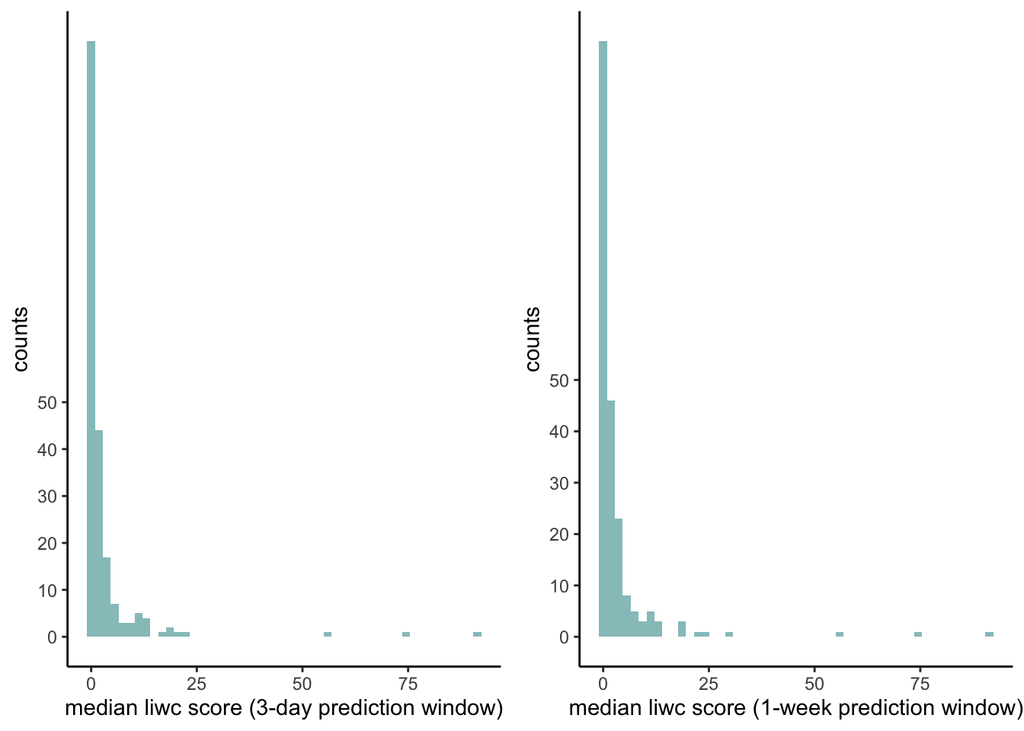

```r
cowplot::plot_grid(
  stats_cat |>
    filter(!str_detect(skim_variable, "wc|wps|analytic|tone|clout|authentic")) |>
    filter(str_detect(skim_variable, "3day")) |>
    # filter(numeric.p50 != 0) |>
    ggplot(aes(x = numeric.p50)) +
    geom_histogram(fill = "#97C4C5", bins = 50) +
    scale_y_continuous(breaks = seq(0, 50, by = 10)) +
    labs(x = "median liwc score (3-day prediction window)", y = "counts"),
  stats_cat |>
    filter(!str_detect(skim_variable, "wc|wps|analytic|tone|clout|authentic")) |>
    filter(str_detect(skim_variable, "1week")) |>
    # filter(numeric.p50 != 0) |>
    ggplot(aes(x = numeric.p50)) +
    geom_histogram(fill = "#97C4C5", bins = 50) +
    scale_y_continuous(breaks = seq(0, 50, by = 10)) +
    labs(x = "median liwc score (1-week prediction window)", y = "counts")
)
```

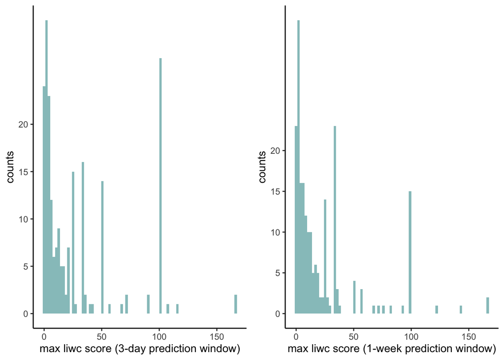

```r
cowplot::plot_grid(
  stats_cat |>
    filter(!str_detect(skim_variable, "wc|wps|analytic|tone|clout|authentic")) |>
    filter(str_detect(skim_variable, "3day")) |>
    ggplot(aes(x = numeric.p100)) +
    geom_histogram(fill = "#97C4C5", bins = 80) +
    scale_y_continuous(breaks = seq(0, 20, by = 5)) +
    labs(x = "max liwc score (3-day prediction window)", y = "counts"),
  stats_cat |>
    filter(!str_detect(skim_variable, "wc|wps|analytic|tone|clout|authentic")) |>
    filter(str_detect(skim_variable, "1week")) |>
    ggplot(aes(x = numeric.p100)) +
    geom_histogram(fill = "#97C4C5", bins = 80) +
    scale_y_continuous(breaks = seq(0, 20, by = 5)) +
    labs(x = "max liwc score (1-week prediction window)", y = "counts")
)
```